# Getting Started with R Markdown

Aakash Prabhu

September 2018

[figure not shown]

# 1 Purpose and Goals

# 2 What is R Markdown?

Simply put, `R Markdown` is a file format to help you create dynamic documents, but with R. It uses simple `Markdown` and embeddable code chunks written in R. It also allows you to use `LaTeX` to typeset mathematical equations. Overall, `R Markdown` produces beautiful documents and academic reports.

We will be using `R Markdown` to write up homework solutions. Since `R Markdown` requires some prior knowledge or familiarity with `Markdown` and `LaTeX`, please make sure you check out how to write in `Markdown` [syntax](https://github.com/adam-p/markdown-here/wiki/Markdown-Cheatsheet), and basic typesetting using `LaTeX` [syntax](https://www.sharelatex.com/learn/latex/Mathematical_expressions).

# 3 Downloading `R-Studio` and `R Markdown`

1. `R Markdown` is an `R Studio` plugin/extension. Be sure to download `R Studio` [here](https://www.rstudio.com/products/rstudio/download/)
2. Follow steps to finish setting up your `R Studio` IDE.
3. Once you have set up the IDE, type the following on your `R Studio` console that you should see on your screen (or on the bottom of your IDE if you have a file open).

```r
install.packages("rmarkdown")
```

[figure not shown]

Console in R Studio

4. Congratulations! You have successfully installed `R Markdown`.

## 3.1 `TeX` Engines

Since students are expected to submit `PDF` files, `R Markdown` requires a `TeX` engine installed. If you are using Windows, please make sure you have `MiKTeX` installed. Alternatively, if you are using a Mac, make sure to install `MacTeX`.

# 4 Creating your first `R Markdown` (`.Rmd`) File

1. To create a new `.Rmd` file in `R Studio`, select `File >> New File >> R Markdown`.
   1. Fill in the Title and Author for your `.Rmd` file.
   2. Select the file type. Since you’re using `R Markdown` to submit homework, select `PDF`
2. By doing this, a minimal `R Markdown` file will be created for you. Here is how it should look.

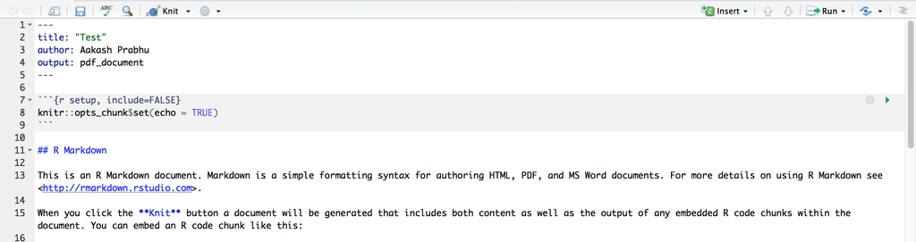

Default RMD File Generated by R Studio

3. If you want to see the PDF the document yields, click on the `Knit` button.
4. Congratulations! You’ve knitted your first `.Rmd` file to create a minimal `PDF` file.

## 4.1 The `YAML` Header

The first few lines in your `.Rmd` file that you see encapsulated within the `---` lines, is known as the `YAML` Header. This defines the required headers for your `.Rmd` file. For our homework assignments, shall use the following header:

Replace the default `YAML` header with the following:

```r
---
title: "ECS {Course} - Homework 0"
author:  John Doe,  \break \{jdoe\} [at] ucdavis [dot] edu # Name and Email
date: "`r Sys.Date()`"
output:
  pdf_document:
    toc: yes
    toc_depth: 3
---
```

This should be self explanatory. We just define a title for our homework, the author, the date (whenever you knit), and define a default Table of Contents. There might be some pieces inside the *author* section that look strange to you. This is because, we can only define new lines and paranthesis using `LaTeX` syntax.

## 4.2 `.Rmd` File for Homework

1. To make things easier, we have provided you with a template for writing homework. Please follow the template to write your homework. You can find the file in `Canvas` or [here](https://raw.githubusercontent.com/UC-Davis-CS-Tutoring/Academic-Templates/master/R-Markdown/HomeworkTemplate.Rmd).
2. Simply replace the existing contents with the above mentioned `.Rmd` contents from the template file.
3. `Knit` the file to a `PDF` and confirm that everything is fine. You should now have a template homework PDF.

You should see something like this:

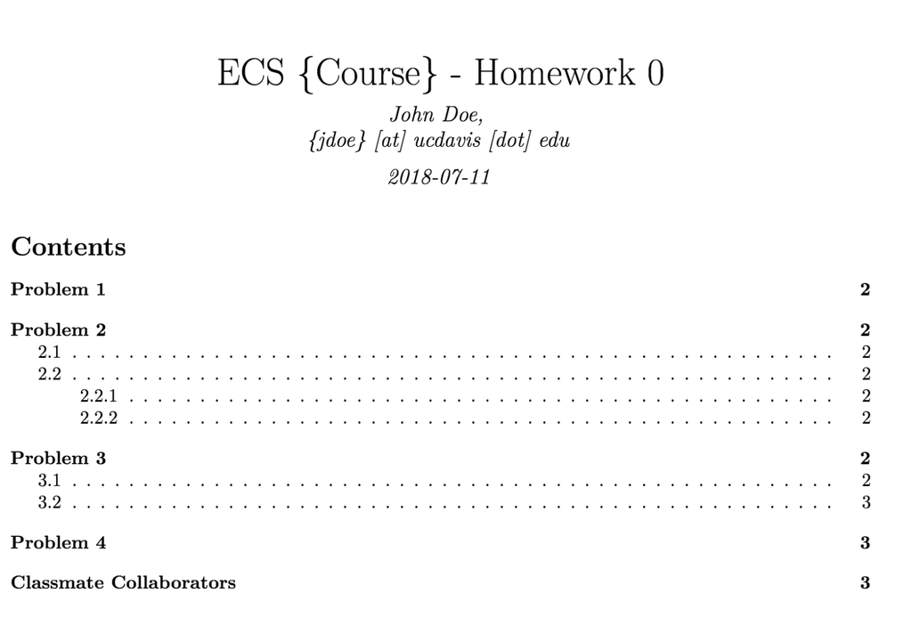

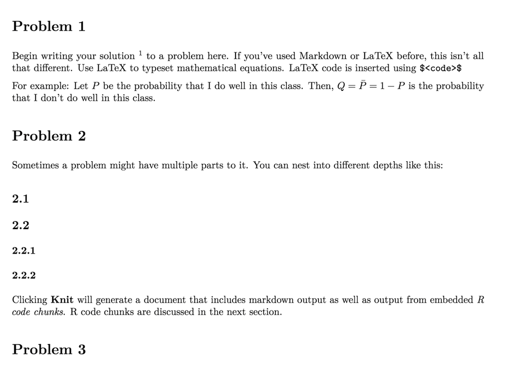

# 5 Typsetting Mathematical Equations using `LaTeX`

Often times you want to write out mathematical equations or proofs. If you want to add typset mathematical equations inline do so by typing `LaTeX` code in between two `$` symbols

```
$ <Latex code> $
```

**For example:** The following `LaTeX` code

```
Let $P$ be the probability that I milk a cow. Then $Q = 1 - P$ is the probability that I don't milk a cow.
```

yields the following:

Let $P$ be the probability that I milk a cow. Then $Q = 1 - P$ is the probability that I don’t milk a cow.

## 5.1 Writing multiple line equations using `LaTeX`

If you want to write mathematical equations that span more than just a single line, you can do so like this:

```
$$
<Multi Line Latex Code Here>
$$
```

**For Example:** The following `LaTeX` code

```
Let $P(A) = 0.5$, $P(B) = 0.2$, $P(A \cap B) = 0.3$.

Then
$$
\begin{split}
P(A \cup B) &= P(A) + P(B) - P(A \cap B) \\
&= 0.5 + 0.2 - 0.3 \\
&= 0.4
\end{split}
]
$$
```

yields the following:

Let $P(A) = 0.5$, $P(B) = 0.2$, $P(A \cap B) = 0.3$.

Then
$$\begin{split}
P(A \cup B) &= P(A) + P(B) - P(A \cap B) \\
&= 0.5 + 0.2 - 0.3 \\
&= 0.4
\end{split}$$

Now, try to create your own multi-line `LaTeX` equation and embed it in your `.Rmd` file.

# 6 Using and Embedding R Code Chunks

Often times, you will be asked to write some sort of R code in your homework. You want to embed your R code in your `.Rmd` file. Any R code that is to be writted and embedded in your `.Rmd` file, should be enclosed within three grave accents that look like this: ` ` `

**Note**: Refer to `Homework_Template.Rmd` located in `Canvas` for a better understanding.

# 7 Final Words

Hopefully this simple tutorial should have gotten you started with getting your homework template `.Rmd` file to knit to a PDF. If you did, congrats! You can start working on the homework now :)

If you have any questions, please post your questions to our [Piazza forum](https://piazza.com/class/jm72jdwi1e95zy).

# 8 References

1. [Our Coding Club’s Tutorial](https://ourcodingclub.github.io/2016/11/24/rmarkdown-1.html)
2. [R Mardown Official Intro](https://rmarkdown.rstudio.com/articles_intro.html)
3. [Documentation for R Markdown](https://rmarkdown.rstudio.com/lesson-1.html)